# R (programming language)

From Wikipedia, the free encyclopedia

R

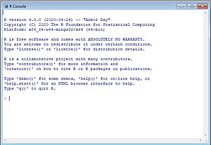

R terminal

[Paradigms](https://en.wikipedia.org/wiki/Programming_paradigm)

[Multi-paradigm](https://en.wikipedia.org/wiki/Multi-paradigm_programming_language): [procedural](https://en.wikipedia.org/wiki/Procedural_programming), [object-oriented](https://en.wikipedia.org/wiki/Object-oriented_programming), [functional](https://en.wikipedia.org/wiki/Functional_programming), [reflective](https://en.wikipedia.org/wiki/Reflective_programming), [imperative](https://en.wikipedia.org/wiki/Imperative_programming), [array](https://en.wikipedia.org/wiki/Array_programming)<sup>[1]</sup>

[Designed by](https://en.wikipedia.org/wiki/Software_design)

[Ross Ihaka](https://en.wikipedia.org/wiki/Ross_Ihaka) and Robert Gentleman

[Developer](https://en.wikipedia.org/wiki/Software_developer)

R Core Team

First appeared

August 1993; 28 years ago

[Stable release](https://en.wikipedia.org/wiki/Software_release_life_cycle)

4.2.1<sup>[2]</sup> / 23 June 2022; 28 days ago

[Typing discipline](https://en.wikipedia.org/wiki/Type_system)

[Dynamic](https://en.wikipedia.org/wiki/Dynamic_typing)

[Platform](https://en.wikipedia.org/wiki/Computing_platform)

[arm64](https://en.wikipedia.org/wiki/Arm64) and [x86-64](https://en.wikipedia.org/wiki/X86-64)

[License](https://en.wikipedia.org/wiki/Software_license)

[GNU GPL v2](https://en.wikipedia.org/wiki/GNU_GPL#Version_2)

[Filename extensions](https://en.wikipedia.org/wiki/Filename_extension)

- .r<sup>[3]</sup>
- .rdata
- .rds
- .rda<sup>[4]</sup>

Website

[www.r-project.org](https://www.r-project.org/)

Influenced by

- Lisp
- S
- Scheme

Influenced

Julia<sup>[5]</sup>

- [R Programming](https://en.wikibooks.org/wiki/R_Programming) at Wikibooks

**R** is a [programming language](https://en.wikipedia.org/wiki/Programming_language) for [statistical computing](https://en.wikipedia.org/wiki/Statistical_computing) and graphics supported by the R Core Team and the R Foundation for Statistical Computing. Created by statisticians [Ross Ihaka](https://en.wikipedia.org/wiki/Ross_Ihaka) and Robert Gentleman, R is used among [data miners](https://en.wikipedia.org/wiki/Data_mining), [bioinformaticians](https://en.wikipedia.org/wiki/Bioinformatics) and [statisticians](https://en.wikipedia.org/wiki/Statistician) for [data analysis](https://en.wikipedia.org/wiki/Data_analysis) and developing [statistical software](https://en.wikipedia.org/wiki/Statistical_software).<sup>[6]</sup> Users have created packages to augment the functions of the R language.

According to user surveys and studies of scholarly literature databases, R is one of the most commonly used programming languages used in data mining.<sup>[7]</sup> As of March 2022, R ranks 11th in the [TIOBE index](https://en.wikipedia.org/wiki/TIOBE_index), a measure of programming language popularity, in which the language peaked in 8th place in August 2020.<sup>[8]</sup><sup>[9]</sup>

The official R software environment is an open-source [free software](https://en.wikipedia.org/wiki/Free_software) environment within the [GNU package](https://en.wikipedia.org/wiki/List_of_GNU_packages), available under the [GNU General Public License](https://en.wikipedia.org/wiki/GNU_General_Public_License). It is written primarily in C, Fortran, and R itself (partially self-hosting). Precompiled [executables](https://en.wikipedia.org/wiki/Executable) are provided for various [operating systems](https://en.wikipedia.org/wiki/Operating_system). R has a [command line interface](https://en.wikipedia.org/wiki/Command_line_interface).<sup>[10]</sup> Multiple third-party [graphical user interfaces](https://en.wikipedia.org/wiki/Graphical_user_interface) are also available, such as RStudio, an [integrated development environment](https://en.wikipedia.org/wiki/Integrated_development_environment), and Jupyter, a [notebook interface](https://en.wikipedia.org/wiki/Notebook_interface).

## History[edit]

R is an open-source implementation of the S programming language combined with [lexical scoping](https://en.wikipedia.org/wiki/Lexical_scoping) semantics from Scheme, which allow objects to be defined in predetermined blocks rather than the entirety of the code.<sup>[1]</sup> S was created by Rick Becker, John Chambers, Doug Dunn, Jean McRae, and Judy Schilling at [Bell Labs](https://en.wikipedia.org/wiki/Bell_Laboratories) around 1976. Designed for statistical analysis, the language is an interpreted language whose code could be directly run without a [compiler](https://en.wikipedia.org/wiki/Compiler).<sup>[11]</sup> Many programs written for S run unaltered in R.<sup>[10]</sup> As a dialect of the Lisp language, Scheme was created by [Gerald J. Sussman](https://en.wikipedia.org/wiki/Gerald_Jay_Sussman) and [Guy L. Steele Jr.](https://en.wikipedia.org/wiki/Guy_L._Steele_Jr.) at [MIT](https://en.wikipedia.org/wiki/Massachusetts_Institute_of_Technology) around 1975.<sup>[12]</sup>

In 1991, statisticians [Ross Ihaka](https://en.wikipedia.org/wiki/Ross_Ihaka) and Robert Gentleman at the [University of Auckland](https://en.wikipedia.org/wiki/University_of_Auckland), New Zealand, embarked on an S implementation.<sup>[13]</sup> It was named partly after the first names of the first two R authors and partly as a play on the name of S.<sup>[10]</sup> They began publicizing it on the data archive StatLib and the *s-news* mailing list in August 1993.<sup>[14]</sup> In 1995, statistician Martin Mächler convinced Ihaka and Gentleman to make R [free and open-source software](https://en.wikipedia.org/wiki/Free_and_open-source_software) under the [GNU General Public License](https://en.wikipedia.org/wiki/GNU_General_Public_License).<sup>[14]</sup><sup>[15]</sup><sup>[16]</sup> The first official release came in June 1995.<sup>[14]</sup> The first official ["stable beta"](https://en.wikipedia.org/wiki/Software_release_life_cycle#BETA) version (v1.0) was released on 29 February 2000.<sup>[17]</sup><sup>[18]</sup>

The Comprehensive R Archive Network (CRAN) was officially announced on 23 April 1997. CRAN stores R's executable files, source code, documentations, as well as packages contributed by users. CRAN originally had 3 mirrors and 12 contributed packages.<sup>[19]</sup> As of January 2022, it has 101 mirrors<sup>[20]</sup> and 18,728 contributed packages.<sup>[21]</sup> In addition to hosting packages CRAN hosts binaries for major distributions of Linux, MacOS X, and Windows.<sup>[22]</sup>

The R Core Team was formed in 1997 to further develop the language.<sup>[10]</sup><sup>[23]</sup> As of January 2022, it consists of Chambers, Gentleman, Ihaka, and Mächler, plus statisticians Douglas Bates, [Peter Dalgaard](https://en.wikipedia.org/wiki/Peter_Dalgaard), [Kurt Hornik](https://en.wikipedia.org/w/index.php?title=Kurt_Hornik&action=edit&redlink=1), Michael Lawrence, Friedrich Leisch, Uwe Ligges, Thomas Lumley, Sebastian Meyer, Paul Murrell, Martyn Plummer, [Brian Ripley](https://en.wikipedia.org/wiki/Brian_Ripley), Deepayan Sarkar, Duncan Temple Lang, [Luke Tierney](https://en.wikipedia.org/wiki/Luke_Tierney), and Simon Urbanek, as well as computer scientist Tomas Kalibera. Stefano Iacus, Guido Masarotto, Heiner Schwarte, Seth Falcon, Martin Morgan, and Duncan Murdoch were members.<sup>[14]</sup><sup>[24]</sup> In April 2003,<sup>[25]</sup> the R Foundation was founded as a non-profit organization to provide further support for the R project.<sup>[10]</sup>

## Features[edit]

### Data processing[edit]

R's [data structures](https://en.wikipedia.org/wiki/Data_structure) include [vectors](https://en.wikipedia.org/wiki/Column_vector), [arrays](https://en.wikipedia.org/wiki/Array_data_structure), lists, and data frames.<sup>[26]</sup> Vectors are ordered collections of values and can be mapped to arrays of one or more dimensions in a [column major order](https://en.wikipedia.org/wiki/Row-_and_column-major_order). That is, given an ordered collection of dimensions, one fills in values along the first dimension first, then fill in one-dimensional arrays across the second dimension, and so on.<sup>[27]</sup> R supports array arithmetics and in this regard is like languages such as APL and MATLAB.<sup>[26]</sup><sup>[28]</sup> The special case of an array with two dimensions is called a matrix. Lists serve as collections of objects that do not necessarily have the same [data type](https://en.wikipedia.org/wiki/Data_type). Data frames contain a list of vectors of the same length, plus a unique set of row names.<sup>[26]</sup> R has no scalar data type.<sup>[29]</sup> Instead, a scalar is represented as a length-one vector.<sup>[30]</sup>

R and its libraries implement various statistical techniques, including [linear](https://en.wikipedia.org/wiki/Linear), [generalized linear](https://en.wikipedia.org/wiki/Generalized_linear_model) and [nonlinear](https://en.wikipedia.org/wiki/Nonlinear) modeling, classical [statistical tests](https://en.wikipedia.org/wiki/Statistical_hypothesis_testing), [spatial](https://en.wikipedia.org/wiki/Spatial_analysis) and [time-series analysis](https://en.wikipedia.org/wiki/Time-series_analysis), classification, [clustering](https://en.wikipedia.org/wiki/Cluster_analysis), and others. For computationally intensive tasks, C, [C++](https://en.wikipedia.org/wiki/C%2B%2B), and Fortran code can be linked and called at run time. Another of R's strengths is static [graphics](https://en.wikipedia.org/wiki/Data_visualization); it can produce publication-quality graphs that include mathematical symbols.<sup>[31]</sup>

### Programming[edit]

R is an [interpreted language](https://en.wikipedia.org/wiki/Interpreted_language); users can access it through a [command-line interpreter](https://en.wikipedia.org/wiki/Command-line_interpreter). If a user types `2+2` at the R command prompt and presses enter, the computer replies with 4.

R supports [procedural programming](https://en.wikipedia.org/wiki/Procedural_programming) with functions and, for some functions, [object-oriented programming](https://en.wikipedia.org/wiki/Object-oriented_programming) with [generic functions](https://en.wikipedia.org/wiki/Generic_function).<sup>[32]</sup> Due to its S heritage, R has stronger [object-oriented programming](https://en.wikipedia.org/wiki/Object-oriented_programming) facilities than most statistical computing languages.<sup>[*[citation needed](https://en.wikipedia.org/wiki/Wikipedia:Citation_needed)*]</sup> Extending it is facilitated by its [lexical scoping](https://en.wikipedia.org/wiki/Lexical_scoping) rules, which are derived from Scheme.<sup>[33]</sup> R uses S-expressions to represent both data and code.<sup>[*[citation needed](https://en.wikipedia.org/wiki/Wikipedia:Citation_needed)*]</sup> R's extensible object system includes objects for (among others): [regression models](https://en.wikipedia.org/wiki/Regression_analysis), [time-series](https://en.wikipedia.org/wiki/Time-series) and [geo-spatial coordinates](https://en.wikipedia.org/wiki/Spatial_analysis). Advanced users can write C, C++,<sup>[34]</sup> Java,<sup>[35]</sup> [.NET](https://en.wikipedia.org/wiki/.NET_Framework)<sup>[36]</sup> or Python code to manipulate R objects directly.<sup>[37]</sup>

Functions are [first-class](https://en.wikipedia.org/wiki/First-class_functions) objects and can be manipulated in the same way as data objects, facilitating [meta-programming](https://en.wikipedia.org/wiki/Meta-programming) that allows [multiple dispatch](https://en.wikipedia.org/wiki/Multiple_dispatch). Function arguments are passed by value, and are [lazy](https://en.wikipedia.org/wiki/Lazy_evaluation)—that is to say, they are only evaluated when they are used, not when the function is called.<sup>[38]</sup> A generic function acts differently depending on the classes of the arguments passed to it. In other words, the generic function [dispatches](https://en.wikipedia.org/wiki/Dynamic_dispatch) the method implementation specific to that object's class. For example, R has a [generic](https://en.wikipedia.org/wiki/Generic_function) `print` function that can print almost every class of object in R with `print(objectname)`.<sup>[39]</sup> Many of R's standard functions are written in R,<sup>[*[citation needed](https://en.wikipedia.org/wiki/Wikipedia:Citation_needed)*]</sup> which makes it easy for users to follow the algorithmic choices made. R is highly extensible through the use of packages for specific functions and specific applications.

## Packages[edit]

Main article: [R package](https://en.wikipedia.org/wiki/R_package)

R's capabilities are extended through user-created<sup>[40]</sup> *packages*, which offer statistical techniques, graphical devices, import/export, reporting (RMarkdown, [knitr](https://en.wikipedia.org/wiki/Knitr), Sweave), etc. These packages and their easy installation and use has been cited as driving the language's widespread adoption in [data science](https://en.wikipedia.org/wiki/Data_science).<sup>[41]</sup><sup>[42]</sup><sup>[43]</sup><sup>[44]</sup><sup>[45]</sup> The packaging system is also used by researchers to organize research data, code and report files in a systematic way for sharing and archiving.<sup>[46]</sup>

Multiple packages are included with the basic installation. Additional packages are available on CRAN,<sup>[20]</sup> Bioconductor, R-Forge,<sup>[47]</sup> Omegahat,<sup>[48]</sup> GitHub, and other repositories.<sup>[49]</sup><sup>[50]</sup><sup>[51]</sup>

The "Task Views" on the CRAN website<sup>[52]</sup> lists packages in fields including Finance, Genetics, High Performance Computing, Machine Learning, Medical Imaging, [Meta-Analysis](https://en.wikipedia.org/wiki/Meta-analysis),<sup>[53]</sup> Social Sciences and Spatial Statistics.<sup>[53]</sup> R has been identified by the [FDA](https://en.wikipedia.org/wiki/Food_and_Drug_Administration) as suitable for interpreting data from clinical research.<sup>[54]</sup> Microsoft maintains a daily snapshot of CRAN that dates back to Sept. 17, 2014.<sup>[55]</sup>

Other R package resources include R-Forge,<sup>[56]</sup><sup>[47]</sup> a platform for the collaborative development of R packages. The Bioconductor project provides packages for genomic data analysis, including object-oriented data-handling and analysis tools for data from Affymetrix, [cDNA](https://en.wikipedia.org/wiki/Complementary_DNA) [microarray](https://en.wikipedia.org/wiki/Microarray), and next-generation [high-throughput sequencing](https://en.wikipedia.org/wiki/High-throughput_sequencing) methods.<sup>[57]</sup>

A group of packages called the Tidyverse, which can be considered a "dialect" of the R language, is increasingly popular among developers.<sup>[note 1]</sup> It strives to provide a cohesive collection of functions to deal with common data science tasks, including data import, cleaning, transformation and visualisation (notably with the [ggplot2](https://en.wikipedia.org/wiki/Ggplot2) package). Dynamic and interactive graphics are available through additional packages.<sup>[58]</sup>

R is one of 5 languages with an [Apache Spark](https://en.wikipedia.org/wiki/Apache_Spark) API, along with Scala, Java, Python, and SQL.<sup>[59]</sup><sup>[60]</sup>

## Milestones[edit]

A list of changes in R releases is maintained in various "news" files at CRAN.<sup>[61]</sup> Some highlights are listed below for several major releases.

[output not shown]

## Interfaces[edit]

Various applications can be used to edit or run R code.<sup>[69]</sup>

Early developers preferred to run R via the command line console,<sup>[70]</sup> succeeded by those who prefer an [IDE](https://en.wikipedia.org/wiki/Integrated_development_environment).<sup>[71]</sup> IDEs for R include (in alphabetical order) [Rattle GUI](https://en.wikipedia.org/wiki/Rattle_GUI), [R Commander](https://en.wikipedia.org/wiki/R_Commander), RKWard, RStudio, and Tinn-R.<sup>[70]</sup> R is also supported in multi-purpose IDEs such as Eclipse via the StatET plugin,<sup>[72]</sup> and [Visual Studio](https://en.wikipedia.org/wiki/Microsoft_Visual_Studio) via the [R Tools for Visual Studio](https://en.wikipedia.org/wiki/R_Tools_for_Visual_Studio).<sup>[73]</sup> Of these, RStudio is the most commonly used.<sup>[71]</sup>

Editors that support R include [Emacs](https://en.wikipedia.org/wiki/Emacs_Speaks_Statistics), Vim (Nvim-R plugin),<sup>[74]</sup> Kate,<sup>[75]</sup> LyX,<sup>[76]</sup> [Notepad++](https://en.wikipedia.org/wiki/Notepad%2B%2B),<sup>[77]</sup> [Visual Studio Code](https://en.wikipedia.org/wiki/Visual_Studio_Code), WinEdt,<sup>[78]</sup> and Tinn-R.<sup>[79]</sup> [Jupyter Notebook](https://en.wikipedia.org/wiki/Jupyter) can also be configured to edit and run R code.<sup>[80]</sup>

R functionality is accessible from scripting languages including Python,<sup>[81]</sup> Perl,<sup>[82]</sup> Ruby,<sup>[83]</sup> F#,<sup>[84]</sup> and Julia.<sup>[85]</sup> Interfaces to other, high-level programming languages, like Java<sup>[86]</sup> and .NET C#<sup>[87]</sup><sup>[88]</sup> are available.

## Implementations[edit]

The main R implementation is written in R, C, and Fortran.<sup>[89]</sup> Several other implementations aimed at improving speed or increasing extensibility. A closely related implementation is pqR (pretty quick R) by [Radford M. Neal](https://en.wikipedia.org/wiki/Radford_M._Neal) with improved memory management and support for automatic multithreading. Renjin and FastR are Java implementations of R for use in a [Java Virtual Machine](https://en.wikipedia.org/wiki/Java_virtual_machine). CXXR, rho, and Riposte<sup>[90]</sup> are implementations of R in [C++](https://en.wikipedia.org/wiki/C%2B%2B). Renjin, Riposte, and pqR attempt to improve performance by using multiple cores and deferred evaluation.<sup>[91]</sup> Most of these alternative implementations are experimental and incomplete, with relatively few users, compared to the main implementation maintained by the R Development Core Team.

[TIBCO](https://en.wikipedia.org/wiki/TIBCO_Software), who previous sold the commercial implementation S-PLUS, built a [runtime engine](https://en.wikipedia.org/wiki/Runtime_engine) called TERR, which is part of Spotfire.<sup>[92]</sup>

Microsoft R Open (MRO) is a fully compatible R distribution with modifications for multi-threaded computations.<sup>[93]</sup><sup>[94]</sup> As of 30 June 2021, Microsoft started to phase out MRO in favor of the CRAN distribution.<sup>[95]</sup>

## Communities[edit]

R has local communities worldwide for users to network, share ideas, and learn.<sup>[96]</sup><sup>[97]</sup>

A growing number of R events bring users together, such as conferences (e.g. useR!, WhyR?, conectaR, SatRdays),<sup>[98]</sup><sup>[99]</sup> meetups,<sup>[100]</sup> as well as [R-Ladies](https://en.wikipedia.org/wiki/R-Ladies_Global) groups<sup>[101]</sup> that promote [gender diversity](https://en.wikipedia.org/wiki/Gender_diversity). The R Foundation taskforce focuses on women and other under-represented groups.<sup>[102]</sup>

## useR! conferences[edit]

The official annual gathering of R users is called "useR!".<sup>[103]</sup> The first such event was useR! 2004 in May 2004, Vienna, Austria.<sup>[104]</sup> After skipping 2005, the useR! conference has been held annually, usually alternating between locations in Europe and North America.<sup>[105]</sup> History:<sup>[103]</sup>

- useR! 2006, Vienna, Austria
- useR! 2007, Ames, Iowa, US
- useR! 2008, Dortmund, Germany
- useR! 2009, Rennes, France
- useR! 2010, Gaithersburg, Maryland, US
- useR! 2011, Coventry, United Kingdom
- useR! 2012, Nashville, Tennessee, US
- useR! 2013, Albacete, Spain
- useR! 2014, Los Angeles, California, US
- useR! 2015, Aalborg, Denmark
- useR! 2016, Stanford, California, US
- useR! 2017, Brussels, Belgium
- useR! 2018, Brisbane, Australia
- useR! 2019, Toulouse, France
- useR! 2020, took place online due to COVID-19 pandemic
- useR! 2021, took place online due to COVID-19 pandemic

The next useR! event is set to take place online in late June, 2022.<sup>[106]</sup>

## *The R Journal*[edit]

*[The R Journal](https://en.wikipedia.org/wiki/The_R_Journal)* is an [open access](https://en.wikipedia.org/wiki/Open_access), [refereed](https://en.wikipedia.org/wiki/Academic_journal) journal of the R project. It features short to medium length articles on the use and development of R, including packages, programming tips, CRAN news, and foundation news.

## Comparison with alternatives[edit]

R is comparable to popular commercial statistical packages such as SAS, SPSS, and Stata. One difference is that R is available at no charge under a [free software license](https://en.wikipedia.org/wiki/Free_software_license).<sup>[107]</sup>

In January 2009, the *[New York Times](https://en.wikipedia.org/wiki/New_York_Times)* ran an article charting the growth of R, the reasons for its popularity among data scientists and the threat it poses to commercial statistical packages such as SAS.<sup>[108]</sup> In June 2017 data scientist Robert Muenchen published a more in-depth comparison between R and other software packages, "The Popularity of Data Science Software".<sup>[109]</sup>

R is more procedural than either SAS or SPSS, both of which make heavy use of pre-programmed procedures (called "procs") that are built-in to the language environment and customized by parameters of each call. R generally processes data in-memory, which limits its usefulness in processing larger files.<sup>[110]</sup>

## Commercial support[edit]

Although R is an [open-source](https://en.wikipedia.org/wiki/Open-source) project, some companies provide commercial support and extensions.

In 2007, Richard Schultz, Martin Schultz, Steve Weston and Kirk Mettler founded [Revolution Analytics](https://en.wikipedia.org/wiki/Revolution_Analytics) to provide commercial support for Revolution R, their distribution of R, which includes components developed by the company. Major additional components include: ParallelR, the R Productivity Environment IDE, RevoScaleR (for [big data](https://en.wikipedia.org/wiki/Big_data) analysis), RevoDeployR, web services framework, and the ability for reading and writing data in the SAS file format.<sup>[111]</sup> Revolution Analytics offers an R distribution designed to comply with established [IQ/OQ/PQ](https://en.wikipedia.org/wiki/Verification_and_validation) criteria that enables clients in the pharmaceutical sector to validate their installation of REvolution R.<sup>[112]</sup> In 2015, [Microsoft Corporation](https://en.wikipedia.org/wiki/Microsoft_Corporation) acquired Revolution Analytics<sup>[113]</sup> and integrated the R programming language into [SQL Server](https://en.wikipedia.org/wiki/SQL_Server), [Power BI](https://en.wikipedia.org/wiki/Power_BI), [Azure SQL Managed Instance](https://en.wikipedia.org/wiki/Azure_SQL_Managed_Instance), [Azure Cortana Intelligence](https://en.wikipedia.org/wiki/Azure_Cortana_Intelligence), Microsoft ML Server and [Visual Studio 2017](https://en.wikipedia.org/wiki/Visual_Studio_2017).<sup>[114]</sup>

In October 2011, [Oracle](https://en.wikipedia.org/wiki/Oracle_Corporation) announced the *Big Data Appliance*, which integrates R, [Apache Hadoop](https://en.wikipedia.org/wiki/Apache_Hadoop), [Oracle Linux](https://en.wikipedia.org/wiki/Oracle_Linux), and a NoSQL database with Exadata hardware.<sup>[115]</sup> As of 2012, [Oracle R Enterprise](https://en.wikipedia.org/wiki/Oracle_R_Enterprise)<sup>[116]</sup> became one of two components of the "Oracle Advanced Analytics Option"<sup>[117]</sup> (alongside [Oracle Data Mining](https://en.wikipedia.org/wiki/Oracle_Data_Mining)).<sup>[*[citation needed](https://en.wikipedia.org/wiki/Wikipedia:Citation_needed)*]</sup>

IBM offers support for in-Hadoop execution of R,<sup>[118]</sup> and provides a programming model for massively parallel in-database analytics in R.<sup>[119]</sup>

[TIBCO](https://en.wikipedia.org/wiki/Tibco_Software) offers a runtime-version R as a part of Spotfire.<sup>[120]</sup>

Mango Solutions offers a validation package for R, ValidR,<sup>[121]</sup><sup>[122]</sup> to comply with drug approval agencies, such as the FDA. These agencies required the use of validated software, as attested by the vendor or sponsor.<sup>[123]</sup>

## Examples[edit]

### Basic syntax[edit]

The following examples illustrate the basic [syntax of the language](https://en.wikipedia.org/wiki/Programming_language_syntax) and use of the command-line interface. (An expanded list of standard language features can be found in the R manual, "An Introduction to R".<sup>[124]</sup>)

In R, the generally preferred assignment operator is an arrow made from two characters `<-`, although `=` can be used in some cases.<sup>[125]</sup><sup>[126]</sup>

```
> x <- 1:6 # Create a numeric vector in the current environment
> y <- x^2 # Create vector based on the values in x.
> print(y) # Print the vector’s contents.
[1]  1  4  9 16 25 36

> z <- x + y # Create a new vector that is the sum of x and y
> z # Return the contents of z to the current environment.
[1]  2  6 12 20 30 42

> z_matrix <- matrix(z, nrow=3) # Create a new matrix that turns the vector z into a 3x2 matrix object
> z_matrix
     [,1] [,2]
[1,]    2   20
[2,]    6   30
[3,]   12   42

> 2*t(z_matrix)-2 # Transpose the matrix, multiply every element by 2, subtract 2 from each element in the matrix, and return the results to the terminal.
     [,1] [,2] [,3]
[1,]    2   10   22
[2,]   38   58   82

> new_df <- data.frame(t(z_matrix), row.names=c('A','B')) # Create a new data.frame object that contains the data from a transposed z_matrix, with row names 'A' and 'B'
> names(new_df) <- c('X','Y','Z') # Set the column names of new_df as X, Y, and Z.
> print(new_df)  # Print the current results.
   X  Y  Z
A  2  6 12
B 20 30 42

> new_df$Z # Output the Z column
[1] 12 42

> new_df$Z==new_df['Z'] && new_df[3]==new_df$Z # The data.frame column Z can be accessed using $Z, ['Z'], or [3] syntax, and the values are the same.
[1] TRUE

> attributes(new_df) # Print attributes information about the new_df object
$names
[1] "X" "Y" "Z"

$row.names
[1] "A" "B"

$class
[1] "data.frame"

> attributes(new_df)$row.names <- c('one','two') # Access and then change the row.names attribute; can also be done using rownames()
> new_df
     X  Y  Z
one  2  6 12
two 20 30 42
```

### Structure of a function[edit]

One of R's strengths is the ease of creating new functions. Objects in the function body remain local to the function, and any data type may be returned.<sup>[127]</sup> Example:

```
# Declare function “f” with parameters “x”, “y“
# that returns a linear combination of x and y.
f <- function(x, y) {
  z <- 3 * x + 4 * y
  return(z) ## the return() function is optional here
}
```

```
> f(1, 2)
[1] 11

> f(c(1,2,3), c(5,3,4))
[1] 23 18 25

> f(1:3, 4)
[1] 19 22 25
```

### Modeling and plotting[edit]

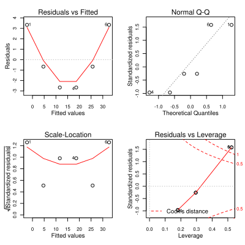

Diagnostic plots from plotting “model” (q.v. “plot.lm()” function). Notice the mathematical notation allowed in labels (lower left plot).

[output not shown]

### Mandelbrot set[edit]

Short R code calculating [Mandelbrot set](https://en.wikipedia.org/wiki/Mandelbrot_set) through the first 20 iterations of equation *z* = *z*<sup>2</sup> + *c* plotted for different complex constants *c*. This example demonstrates:

[figure not shown]

"Mandelbrot.gif" – graphics created in R with 14 lines of code in Example 2

- use of community-developed external libraries (called packages), in this case caTools package
- handling of [complex numbers](https://en.wikipedia.org/wiki/Complex_numbers)
- multidimensional arrays of numbers used as basic data type, see variables `C`, `Z` and `X`.

```
install.packages("caTools")  # install external package
library(caTools)             # external package providing write.gif function
jet.colors <- colorRampPalette(c("green", "pink", "#007FFF", "cyan", "#7FFF7F",
                                 "white", "#FF7F00", "red", "#7F0000"))
dx <- 1500                    # define width
dy <- 1400                    # define height
C  <- complex(real = rep(seq(-2.2, 1.0, length.out = dx), each = dy),
              imag = rep(seq(-1.2, 1.2, length.out = dy), dx))
C <- matrix(C, dy, dx)       # reshape as square matrix of complex numbers
Z <- 0                       # initialize Z to zero
X <- array(0, c(dy, dx, 20)) # initialize output 3D array
for (k in 1:20) {            # loop with 20 iterations
  Z <- Z^2 + C               # the central difference equation
  X[, , k] <- exp(-abs(Z))   # capture results
}
write.gif(X, "Mandelbrot.gif", col = jet.colors, delay = 100)
```

## See also[edit]

- [R package](https://en.wikipedia.org/wiki/R_package)
- [Comparison of numerical-analysis software](https://en.wikipedia.org/wiki/Comparison_of_numerical-analysis_software)
- [Comparison of statistical packages](https://en.wikipedia.org/wiki/Comparison_of_statistical_packages)
- [List of numerical-analysis software](https://en.wikipedia.org/wiki/List_of_numerical-analysis_software)
- [List of statistical software](https://en.wikipedia.org/wiki/List_of_statistical_software)
- Rmetrics

## Notes[edit]

1. **^** As of 13 June 2020, [Metacran](https://www.r-pkg.org/downloaded) listed 7 of the 8 core packages of the Tidyverse in the list of most download R packages.

## References[edit]

1. ^ Jump up to: <sup>**a**</sup> <sup>**b**</sup> Morandat, Frances; Hill, Brandon; Osvald, Leo; Vitek, Jan (11 June 2012). ["Evaluating the design of the R language: objects and functions for data analysis"](https://doi.org/10.1007/978-3-642-31057-7_6). *European Conference on Object-Oriented Programming*. **2012**: 104–131. doi:[10.1007/978-3-642-31057-7_6](https://doi.org/10.1007%2F978-3-642-31057-7_6). Retrieved 17 May 2016 – via SpringerLink.
2. **^** Peter Dalgaard (23 June 2022). ["R 4.2.1 is released"](https://stat.ethz.ch/pipermail/r-announce/2022/000685.html). Retrieved 23 June 2022.
3. **^** ["R scripts"](http://mercury.webster.edu/aleshunas/R_learning_infrastructure/R%20scripts.html). *mercury.webster.edu*. Retrieved 17 July 2021.
4. **^** ["R Data Format Family (.rdata, .rda)"](https://www.loc.gov/preservation/digital/formats/fdd/fdd000470.shtml). *Loc.gov*. 9 June 2017. Retrieved 17 July 2021.
5. **^** ["Introduction"](https://web.archive.org/web/20180620172516/https://docs.julialang.org/en/stable/manual/introduction/#man-introduction-1#man-introduction-1). *The Julia Manual*. Archived from [the original](https://docs.julialang.org/en/stable/manual/introduction/#man-introduction-1) on 20 June 2018. Retrieved 5 August 2018.
6. **^** Giorgi, Federico M.; Ceraolo, Carmine; Mercatelli, Daniele (27 April 2022). ["The R Language: An Engine for Bioinformatics and Data Science"](https://doi.org/10.3390%2Flife12050648). *Life*. **12** (5): 648. doi:[10.3390/life12050648](https://doi.org/10.3390%2Flife12050648). ISSN 2075-1729. PMID 35629316.
7. **^** R's popularity
   - David Smith (2012); [*R Tops Data Mining Software Poll*](https://www.r-bloggers.com/2012/05/r-tops-data-mining-software-poll/), R-bloggers, 31 May 2012.
   - Karl Rexer, Heather Allen, & Paul Gearan (2011); [*2011 Data Miner Survey Summary*](https://www.kdnuggets.com/2012/07/rexer-analytics-2011-data-miner-survey-results.html), presented at Predictive Analytics World, Oct. 2011.
   - Robert A. Muenchen (2012). ["The Popularity of Data Analysis Software"](http://r4stats.com/articles/popularity/).
   - Tippmann, Sylvia (29 December 2014). ["Programming tools: Adventures with R"](https://doi.org/10.1038%2F517109a). *Nature*. **517** (7532): 109–110. doi:[10.1038/517109a](https://doi.org/10.1038%2F517109a). PMID 25557714.
8. **^** ["TIOBE Index - The Software Quality Company"](https://www.tiobe.com/tiobe-index/). *TIOBE*. Retrieved 12 March 2022.: CS1 maint: url-status ()
9. **^** ["TIOBE Index: The R Programming Language"](https://www.tiobe.com/tiobe-index/r/). *TIOBE*. Retrieved 23 May 2022.
10. ^ Jump up to: <sup>**a**</sup> <sup>**b**</sup> <sup>**c**</sup> <sup>**d**</sup> <sup>**e**</sup> Kurt Hornik. [*The R FAQ: Why R?*](https://cran.r-project.org/doc/FAQ/R-FAQ.html#Why-is-R-named-R_003f). ISBN 3-900051-08-9. Retrieved 29 January 2008.
11. **^** Becker, Richard A., [*A Brief History of S*](https://citeseerx.ist.psu.edu/viewdoc/summary?doi=10.1.1.131.1428&rank=6&q=a%20brief%20history%20of%20S&osm=&ossid=), CiteSeerX 10.1.1.131.1428, retrieved 12 January 2022
12. **^** Sussman, Gerald Jay; Steele, Guy L. (1 December 1998). ["The First Report on Scheme Revisited"](https://doi.org/10.1023/A:1010079421970). *Higher-Order and Symbolic Computation*. **11** (4): 399–404. doi:[10.1023/A:1010079421970](https://doi.org/10.1023%2FA%3A1010079421970). ISSN 1573-0557. S2CID 7704398.
13. **^** ["Academic unfazed by rock star status"](https://www.nzherald.co.nz/nz/academic-unfazed-by-rock-star-status/LMU5EIMP7QCMZFCBM3UNW4C7CI/). *NZ Herald*. Retrieved 30 December 2021.
14. ^ Jump up to: <sup>**a**</sup> <sup>**b**</sup> <sup>**c**</sup> <sup>**d**</sup> Ihaka, Ross (1998). [*R : Past and Future History*](https://www.stat.auckland.ac.nz/~ihaka/downloads/Interface98.pdf) (PDF) (Technical report). Statistics Department, The University of Auckland, Auckland, New Zealand.
15. **^** ["R license"](https://www.r-project.org/COPYING). r-project. Retrieved 5 August 2018.
16. **^** GNU project
    - ["GNU R"](http://directory.fsf.org/project/gnur/). Free Software Foundation (FSF) Free Software Directory. 23 April 2018. Retrieved 7 August 2018.
    - R Project (n.d.). ["What is R?"](https://www.r-project.org/about.html). Retrieved 7 August 2018.
17. **^** ["Over 16 years of R Project history"](http://blog.revolutionanalytics.com/2016/03/16-years-of-r-history.html). *Revolutions*. Retrieved 30 May 2016.
18. **^** Ihaka, Ross. ["The R Project: A Brief History and Thoughts About the Future"](https://www.stat.auckland.ac.nz/~ihaka/downloads/Massey.pdf) (PDF). *stat.auckland.ac.nz*.
19. **^** Kurt Hornik (23 April 1997). ["Announce: CRAN"](https://stat.ethz.ch/pipermail/r-announce/1997/000001.html). *r-help*. Wikidata Q101068595..
20. ^ Jump up to: <sup>**a**</sup> <sup>**b**</sup> ["CRAN - Mirrors"](https://cran.r-project.org/mirrors.html). *cran.r-project.org*. Retrieved 15 January 2022.
21. **^** ["CRAN - Contributed Packages"](https://cran.r-project.org/web/packages/index.html). *cran.r-project.org*. Retrieved 3 January 2022.
22. **^** Hornik, Kurt (2012). ["The Comprehensive R Archive Network"](https://onlinelibrary.wiley.com/doi/10.1002/wics.1212). *WIREs Computational Statistics*. **4** (4): 394–398. doi:[10.1002/wics.1212](https://doi.org/10.1002%2Fwics.1212). ISSN 1939-5108. S2CID 62231320.
23. **^** Fox, John (2009). ["Aspects of the Social Organization and Trajectory of the R Project"](https://journal.r-project.org/archive/2009/RJ-2009-014/index.html). *The R Journal*. **1** (2): 5. doi:[10.32614/RJ-2009-014](https://doi.org/10.32614%2FRJ-2009-014). ISSN 2073-4859.
24. **^** ["R: Contributors"](https://www.r-project.org/contributors.html). *R Project*. Retrieved 14 July 2021.
25. **^** Mächler, Martin; Hornik, Kurt (December 2014). ["R Foundation News"](https://journal.r-project.org/archive/2014-2/r-foundation.pdf) (PDF). *The R Journal*. Retrieved 30 December 2021.: CS1 maint: url-status ()
26. ^ Jump up to: <sup>**a**</sup> <sup>**b**</sup> <sup>**c**</sup> Dalgaard, Peter (2002). [*Introductory Statistics with R*](https://archive.org/details/introductorystat00dalg_885). New York, Berlin, Heidelberg: Springer-Verlag. pp. [10](https://archive.org/details/introductorystat00dalg_885/page/n26)–18, 34. ISBN 0387954759.
27. **^** *An Introduction to R*, Section 5.1: Arrays. Retrieved in 2010-03 from https://cran.r-project.org/doc/manuals/R-intro.html#Arrays.
28. **^** Chen, Han-feng; Wai-mee, Ching; Da, Zheng. ["A Comparison Study on Execution Performance of MATLAB and APL"](http://www.sable.mcgill.ca/~hanfeng.c/eli/res/Comparison.pdf) (PDF). *McGill University*. Retrieved 16 February 2022.
29. **^** Ihaka, Ross; Gentlman, Robert (September 1996). ["R: A Language for Data Analysis and Graphics"](https://www.stat.auckland.ac.nz/~ihaka/downloads/R-paper.pdf) (PDF). *Journal of Computational and Graphical Statistics*. American Statistical Association. **5** (3): 299–314. doi:[10.2307/1390807](https://doi.org/10.2307%2F1390807). JSTOR 1390807. Retrieved 12 May 2014.
30. **^** ["Data structures · Advanced R."](http://adv-r.had.co.nz/Data-structures.html) *adv-r.had.co.nz*. Retrieved 26 September 2016.
31. **^** ["R: What is R?"](https://www.r-project.org/about.html). *R-project.org*. Retrieved 17 February 2022.
32. **^** White, Homer. [*14.1 Programming Paradigms | Beginning Computer Science with R*](https://homerhanumat.github.io/r-notes/programming-paradigms.html).
33. **^** Jackman, Simon (Spring 2003). ["R For the Political Methodologist"](https://web.archive.org/web/20060721143309/http://polmeth.wustl.edu/tpm/tpm_v11_n2.pdf) (PDF). *The Political Methodologist*. Political Methodology Section, [American Political Science Association](https://en.wikipedia.org/wiki/American_Political_Science_Association). **11** (1): 20–22. Archived from [the original](http://polmeth.wustl.edu/tpm/tpm_v11_n2.pdf) (PDF) on 21 July 2006. Retrieved 13 September 2018.
34. **^** Eddelbuettel, Dirk; Francois, Romain (2011). ["Rcpp: Seamless R and C++ Integration"](https://doi.org/10.18637%2Fjss.v040.i08). *[Journal of Statistical Software](https://en.wikipedia.org/wiki/Journal_of_Statistical_Software)*. **40** (8). doi:[10.18637/jss.v040.i08](https://doi.org/10.18637%2Fjss.v040.i08).
35. **^** ["nution-j2r: Java library to invoke R native functions"](https://gitlab.nuiton.org/nuiton/nuiton-j2r). Retrieved 13 September 2018.
36. **^** .NET Framework
    - ["Making GUIs using C# and R with the help of R.NET"](http://psychwire.wordpress.com/2011/06/19/making-guis-using-c-and-r-with-the-help-of-r-net/). 19 June 2011. Retrieved 13 September 2018.
    - ["R.NET homepage"](https://web.archive.org/web/20151013020201/http://rdotnet.codeplex.com/). Archived from [the original](http://rdotnet.codeplex.com/) on 13 October 2015. Retrieved 13 September 2018.
    - Haynold, Oliver M. (April 2011). [*An Rserve Client Implementation for CLI/.NET*](https://web.archive.org/web/20151129223447/http://www.rinfinance.com/agenda/2011/OliverHaynold.pdf) (PDF). [R/Finance 2011](http://www.rinfinance.com/RinFinance2011/agenda/). Chicago, IL, USA. Archived from [the original](http://www.rinfinance.com/agenda/2011/OliverHaynold.pdf) (PDF) on 29 November 2015. Retrieved 13 September 2018.
37. **^** R manuals. ["Writing R Extensions"](https://cran.r-project.org/doc/manuals/r-release/R-exts.html). *r-project.org*. Retrieved 13 September 2018.
38. **^** ["Functions · Advanced R."](http://adv-r.had.co.nz/Functions.html#lazy-evaluation) *adv-r.had.co.nz*.
39. **^** R Core Team. ["Print Values"](https://stat.ethz.ch/R-manual/R-devel/library/base/html/print.html). *R Documentation*. R Foundation for Statistical Computing. Retrieved 30 May 2016.
40. **^** Hadley, Wickham; Bryan, Jenny. ["R packages: Organize, Test, Document, and Share Your Code"](https://r-pkgs.org/). : Cite journal requires ()
41. **^** Chambers, John M. (2020). ["S, R, and Data Science"](https://journal.r-project.org/archive/2020/RJ-2020-028/index.html). *The R Journal*. **12** (1): 462–476. doi:[10.32614/RJ-2020-028](https://doi.org/10.32614%2FRJ-2020-028). ISSN 2073-4859.
42. **^** Vance, Ashlee (6 January 2009). ["Data Analysts Captivated by R's Power"](https://www.nytimes.com/2009/01/07/technology/business-computing/07program.html). *[New York Times](https://en.wikipedia.org/wiki/New_York_Times)*.
43. **^** Tippmann, Sylvia (29 December 2014). ["Programming tools: Adventures with R"](https://doi.org/10.1038%2F517109a). *Nature News*. **517** (7532): 109–110. doi:[10.1038/517109a](https://doi.org/10.1038%2F517109a). PMID 25557714.
44. **^** Thieme, Nick (2018). ["R generation"](https://doi.org/10.1111%2Fj.1740-9713.2018.01169.x). *Significance*. **15** (4): 14–19. doi:[10.1111/j.1740-9713.2018.01169.x](https://doi.org/10.1111%2Fj.1740-9713.2018.01169.x). ISSN 1740-9713.
45. **^** widely used
    - Fox, John & Andersen, Robert (January 2005). ["Using the R Statistical Computing Environment to Teach Social Statistics Courses"](https://socialsciences.mcmaster.ca/jfox/Teaching-with-R.pdf) (PDF). Department of Sociology, McMaster University. Retrieved 6 August 2018. : Cite journal requires ()
    - Vance, Ashlee (6 January 2009). ["Data Analysts Captivated by R's Power"](https://www.nytimes.com/2009/01/07/technology/business-computing/07program.html). *[New York Times](https://en.wikipedia.org/wiki/New_York_Times)*. Retrieved 6 August 2018. R is also the name of a popular programming language used by a growing number of data analysts inside corporations and academia. It is becoming their lingua franca...
46. **^** Marwick, Ben; Boettiger, Carl; Mullen, Lincoln (26 August 2017). ["Packaging data analytical work reproducibly using R (and friends)"](https://peerj.com/preprints/3192/?td=wk). *PeerJ Preprints*. doi:[10.7287/peerj.preprints.3192v1](https://doi.org/10.7287%2Fpeerj.preprints.3192v1). ISSN 2167-9843.
47. ^ Jump up to: <sup>**a**</sup> <sup>**b**</sup> Theußl, Stefan; Zeileis, Achim (2009). ["Collaborative Software Development Using R-Forge"](https://journal.r-project.org/archive/2009/RJ-2009-007/index.html). *The R Journal*. **1** (1): 9. doi:[10.32614/RJ-2009-007](https://doi.org/10.32614%2FRJ-2009-007). ISSN 2073-4859.
48. **^** ["Omegahat.net"](http://www.omegahat.net/). Omegahat.net. Retrieved 16 September 2018.
49. **^** packages available from repositories
    - Robert A. Muenchen (2012). ["The Popularity of Data Analysis Software"](http://r4stats.com/articles/popularity/).
    - Tippmann, Sylvia (29 December 2014). ["Programming tools: Adventures with R"](https://doi.org/10.1038%2F517109a). *Nature*. **517** (7532): 109–110. doi:[10.1038/517109a](https://doi.org/10.1038%2F517109a). PMID 25557714.
    - ["Search all R packages and function manuals | Rdocumentation"](http://www.rdocumentation.org/). *Rdocumentation*. 16 June 2014. Retrieved 16 September 2018.
50. **^** Wickham, Hadley; Bryan, Jennifer. [*Chapter 10 Object documentation | R Packages*](https://r-pkgs.org/man.html).
51. **^** ["Rd formatting"](https://cran.r-project.org/web/packages/roxygen2/vignettes/rd-formatting.html). *cran.r-project.org*. Retrieved 16 August 2021.
52. **^** ["CRAN Task Views"](https://cran.r-project.org/web/views/). *cran.r-project.org*. Retrieved 16 September 2018.
53. ^ Jump up to: <sup>**a**</sup> <sup>**b**</sup> Hornik, Kurt; Zeileis, Achim (2013). ["Changes on CRAN"](http://journal.r-project.org/archive/2013-1/cran.pdf) (PDF). *The R Journal*. **5** (1): 239–264.
54. **^** ["FDA: R OK for drug trials"](http://blog.revolutionanalytics.com/2012/06/fda-r-ok.html). Retrieved 16 September 2018.
55. **^** ["CRAN Time Machine. MRAN"](https://mran.microsoft.com/timemachine). Retrieved 26 December 2019.
56. **^** ["R-Forge: Welcome"](https://r-forge.r-project.org/). Retrieved 16 September 2018.
57. **^** Huber, W; Carey, VJ; Gentleman, R; Anders, S; Carlson, M; Carvalho, BS; Bravo, HC; Davis, S; Gatto, L; Girke, T; Gottardo, R; Hahne, F; Hansen, KD; Irizarry, RA; Lawrence, M; Love, MI; MacDonald, J; Obenchain, V; Oleś, AK; Pagès, H; Reyes, A; Shannon, P; Smyth, GK; Tenenbaum, D; Waldron, L; Morgan, M (2015). ["Orchestrating high-throughput genomic analysis with Bioconductor"](https://www.ncbi.nlm.nih.gov/pmc/articles/PMC4509590). *Nature Methods*. [Nature Publishing Group](https://en.wikipedia.org/wiki/Nature_Publishing_Group). **12** (2): 115–121. doi:[10.1038/nmeth.3252](https://doi.org/10.1038%2Fnmeth.3252). PMC 4509590. PMID 25633503.
58. **^** Lewin-Koh, Nicholas (7 January 2015). ["CRAN Task View: Graphic Displays & Dynamic Graphics & Graphic Devices & Visualization"](https://web.archive.org/web/20160926233106/https://cran.r-project.org/web/views/Graphics.html). The Comprehensive R Archive Network. Archived from [the original](https://cran.r-project.org/web/views/Graphics.html) on 26 September 2016. Retrieved 13 September 2018. : Cite journal requires ()
59. **^** ["Spark API Documentation"](https://spark.apache.org/docs/latest/api.html). *Spark*.
60. **^** ["SparkR (R on Spark)"](https://spark.apache.org/docs/latest/sparkr.html). *Spark*.
61. **^** Changes in versions 3.0.0 onward: ["R News"](https://cran.r-project.org/src/base/NEWS). *cran.r-project.org*. Retrieved 3 July 2014. Earlier change logs (by major release number):
    - ["NEWS"](https://cran.r-project.org/src/base/NEWS). *cran.r-project.org*. Retrieved 28 June 2020.
    - ["NEWS.3"](https://cran.r-project.org/src/base/NEWS.3). *cran.r-project.org*. Retrieved 28 June 2020.
    - ["NEWS.2"](https://cran.r-project.org/src/base/NEWS.2). *cran.r-project.org*. Retrieved 8 April 2017.
    - ["NEWS.1"](https://cran.r-project.org/src/base/NEWS.1). *cran.r-project.org*. Retrieved 8 April 2017.
    - ["NEWS.0"](https://cran.r-project.org/src/base/NEWS.0). *cran.r-project.org*. Retrieved 8 April 2017.
62. **^** ["Index of /src/base/R-0"](https://cran.r-project.org/src/base/R-0/). *cran.r-project.org*.
63. **^** ["ANNOUNCE: CRAN"](https://stat.ethz.ch/pipermail/r-announce/1997/000001.html). *stat.ethz.ch*.
64. **^** ["0.99 SERIES NEWS : CHANGES IN R VERSION 0.99.0"](https://cran.r-project.org/src/base/NEWS.0). *Cran.r-project.org*. Retrieved 18 February 2022.
65. **^** Peter Dalgaard. ["R-1.0.0 is released"](https://stat.ethz.ch/pipermail/r-announce/2000/000127.html). *Stat.ethz.ch*. Retrieved 6 June 2009.
66. **^** ["CHANGES IN R VERSION 2.7.0"](https://cran-archive.r-project.org/bin/windows/base/old/2.7.0/CHANGES.R-2.7.0). *Cran-archive.r-project.org*. Retrieved 18 February 2022.
67. **^** ["R FAQ"](https://cran.r-project.org/bin/windows/base/rw-FAQ.html#How-do-I-install-R-for-Windows_003f). *Cran.r-project.org*. Retrieved 20 March 2020.
68. **^** Ottoboni, Kellie; Stark, Philip B. (2018). "Random problems with R". arXiv:1809.06520 [cs.MS].
69. **^** ["Recommendations for Windows text editor for R (StackOverflow)"](https://stackoverflow.com/questions/1173463/recommendations-for-windows-text-editor-for-r). *Stackoverflow.com*. Retrieved 20 December 2020.
70. ^ Jump up to: <sup>**a**</sup> <sup>**b**</sup> ["Poll: R GUIs you use frequently (2011)"](http://www.kdnuggets.com/polls/2011/r-gui-used.html). *kdnuggets.com*. Retrieved 18 September 2018.
71. ^ Jump up to: <sup>**a**</sup> <sup>**b**</sup> ["R Programming - The State of Developer Ecosystem in 2020 Infographic"](https://www.jetbrains.com/lp/devecosystem-2020/). *JetBrains: Developer Tools for Professionals and Teams*. Retrieved 16 August 2021.
72. **^** Stephan Wahlbrink. ["StatET for R"](https://marketplace.eclipse.org/content/statet-r/).
73. **^** ["Work with R in Visual Studio"](https://docs.microsoft.com/en-us/visualstudio/rtvs/?view=vs-2017). Retrieved 14 December 2020.
74. **^** ["Nvim-R - Plugin to work with R : vim online"](https://www.vim.org/scripts/script.php?script_id=2628). *Vim.org*. Retrieved 6 March 2019.
75. **^** ["Syntax Highlighting"](https://web.archive.org/web/20080707062903/http://www.kate-editor.org/downloads/syntax_highlighting). Kate Development Team. Archived from [the original](http://kate-editor.org/downloads/syntax_highlighting) on 7 July 2008. Retrieved 9 July 2008.
76. **^** Paul E. Johnson & Gregor Gorjanc. ["LyX with R through Sweave"](http://wiki.lyx.org/LyX/LyxWithRThroughSweave). Retrieved 4 April 2017.
77. **^** ["NppToR: R in Notepad++"](http://sourceforge.net/projects/npptor/). sourceforge.net. 8 May 2013. Retrieved 18 September 2013.
78. **^** Uwe Ligges (5 January 2017). ["RWinEdt: R Interface to 'WinEdt'"](https://cran.r-project.org/web/packages/RWinEdt/index.html). Retrieved 4 April 2017.
79. **^** ["Tinn-R"](https://nbcgib.uesc.br/tinnr/en/). Retrieved 5 March 2019.
80. **^** ["Using the R programming language in Jupyter Notebook"](https://docs.anaconda.com/anaconda/navigator/tutorials/r-lang/). *Anaconda*. Retrieved 14 September 2020.
81. **^** Gautier, Laurent. ["rpy2 - R in Python"](https://rpy2.github.io/). Retrieved 30 November 2021.: CS1 maint: url-status ()
82. **^** Florent Angly. ["Statistics::R - Perl interface with the R statistical program"](https://metacpan.org/module/Statistics::R). *Metacpan.org*.
83. **^** Alex Gutteridge (15 July 2021). ["GitHub - alexgutteridge/rsruby: Ruby - R bridge"](https://github.com/alexgutteridge/rsruby). *Github.com*.
84. **^** BlueMountain Capital. ["F# R Type Provider"](https://bluemountaincapital.github.io/FSharpRProvider/).
85. **^** ["JuliaInterop/RCall.jl"](https://github.com/JuliaInterop/RCall.jl). *Github.com*. 2 June 2021.
86. **^** ["Rserve - Binary R server - RForge.net"](https://www.rforge.net/Rserve/). *Rforge.net*.
87. **^** ["konne/RserveCLI2"](https://github.com/konne/RserveCLI2). *Github.com*. 8 March 2021.
88. **^** ["R.NET"](https://jmp75.github.io/rdotnet/). *Jmp75.github.io*. Retrieved 18 February 2022.
89. **^** ["r-source: Read only mirror of R source code on GitHub"](https://github.com/wch/r-source). *GitHub*. Retrieved 14 September 2019.
90. **^** Talbot, Justin; DeVito, Zachary; Hanrahan, Pat (1 January 2012). "Riposte: A Trace-driven Compiler and Parallel VM for Vector Code in R". *Proceedings of the 21st International Conference on Parallel Architectures and Compilation Techniques*. ACM: 43–52. doi:[10.1145/2370816.2370825](https://doi.org/10.1145%2F2370816.2370825). S2CID 1989369.
91. **^** Neal, Radford (25 July 2013). ["Deferred evaluation in Renjin, Riposte, and pqR"](https://radfordneal.wordpress.com/2013/07/24/deferred-evaluation-in-renjin-riposte-and-pqr/). *Radford Neal's blog*. Retrieved 6 March 2017.
92. **^** Jackson, Joab (16 May 2013). [TIBCO offers free R to the enterprise](http://www.pcworld.com/article/2038944/tibco-offers-free-r-to-the-enterprise.html). *PC World*. Retrieved 20 July 2015.
93. **^** ["Home"](https://mran.microsoft.com/). *mran.microsoft.com*. Retrieved 22 November 2021.
94. **^** ["Microsoft R Open: The Enhanced R Distribution"](https://mran.microsoft.com/open). Retrieved 30 June 2018.
95. **^** ["Looking to the future for R in Azure SQL and SQL Server"](https://cloudblogs.microsoft.com/sqlserver/2021/06/30/looking-to-the-future-for-r-in-azure-sql-and-sql-server/). 30 June 2021. Retrieved 7 November 2021.
96. **^** ["Local R User Group Directory"](http://blog.revolutionanalytics.com/local-r-groups.html). *Revolutions Blog*. Retrieved 12 May 2018.
97. **^** [*A list of R conferences and meetings*](https://jumpingrivers.github.io/meetingsR/index.html). *Jumping Rivers*. Retrieved 12 May 2018.
98. **^** ["official website of WhyR? conference"](http://whyr.pl/). *WhyR?*. Retrieved 26 June 2019.
99. **^** ["SatRdays listing"](https://satrdays.org/). *SatRdays*. Retrieved 26 June 2019.
100. **^** ["R Project for Statistical Computing"](https://www.meetup.com/topics/r-project-for-statistical-computing/). *Meetup*. Retrieved 12 May 2018.
101. **^** ["R Ladies"](https://rladies.org/). *R Ladies*. Retrieved 12 May 2018.
102. **^** ["Forwards"](https://forwards.github.io/). Retrieved 23 March 2020.
103. ^ Jump up to: <sup>**a**</sup> <sup>**b**</sup> ["R: Conferences"](https://www.r-project.org/conferences/). *r-project.org*. 1 November 2019. Retrieved 19 November 2019.
104. **^** ["useR! 2004 - The R User Conference"](http://www.ci.tuwien.ac.at/Conferences/useR-2004/). 27 May 2004. Retrieved 9 September 2018.
105. **^** R Project (9 August 2013). ["R-related Conferences"](https://www.r-project.org/conferences). Retrieved 15 August 2019.
106. **^** ["useR! 2022"](https://user2022.r-project.org/). *user2022.r-project.org*. Retrieved 11 March 2022.
107. **^** Burns, Patrick (27 February 2007). ["Comparison of R to SAS, Stata and SPSS"](http://www.burns-stat.com/pages/Tutor/R_relative_statpack.pdf) (PDF). Retrieved 18 September 2013.
108. **^** R as competition for commercial statistical packages
     - Vance, Ashlee (7 January 2009). ["Data Analysts Are Mesmerized by the Power of Program R: [Business/Financial Desk]"](https://www.nytimes.com/2009/01/07/technology/business-computing/07program.html). *The New York Times*.
     - Vance, Ashlee (8 January 2009). ["R You Ready for R?"](http://bits.blogs.nytimes.com/2009/01/08/r-you-ready-for-r/). *The New York Times*.
109. **^** Muenchen, Robert (19 June 2017). ["The Popularity of Data Science Software"](http://r4stats.com/articles/popularity/). Retrieved 21 November 2018.
110. **^** ["R vs. SPSS"](https://www.educba.com/r-vs-spss/).
111. **^** Morgan, Timothy Prickett (2011-02-07). "'Red Hat for stats' goes toe-to-toe with SAS". The Register, 7 February 2011. Retrieved from https://www.theregister.co.uk/2011/02/07/revolution_r_sas_challenge/.
112. **^** ["Analyzing clinical trial data for FDA submissions with R"](http://blog.revolutionanalytics.com/2009/01/analyzing-clinical-trial-data-with-r.html). Revolution Analytics. 14 January 2009. Retrieved 20 September 2018.
113. **^** Sirosh, Joseph. ["Microsoft Closes Acquisition of Revolution Analytics"](http://blogs.technet.com/b/machinelearning/archive/2015/04/06/microsoft-closes-acquisition-of-revolution-analytics.aspx). *blogs.technet.com*. Microsoft. Retrieved 20 September 2018.
114. **^** ["Introducing R Tools for Visual Studio"](https://blogs.msdn.microsoft.com/visualstudio/2016/03/22/introducing-r-tools-for-visual-studio-3/). Retrieved 20 September 2018.
115. **^** Oracle Corporation's Big Data Appliance
     - Doug Henschen (2012); [*Oracle Makes Big Data Appliance Move With Cloudera*](http://www.informationweek.com/software/information-management/oracle-makes-big-data-appliance-move-wit/232400021), InformationWeek, 10 January 2012.
     - Jaikumar Vijayan (2012); [*Oracle's Big Data Appliance brings focus to bundled approach*](http://www.computerworld.com/s/article/9223325/Oracle_s_Big_Data_Appliance_brings_focus_to_bundled_approach), ComputerWorld, 11 January 2012.
     - Timothy Prickett Morgan (2011); [Oracle rolls its own NoSQL and Hadoop *Oracle rolls its own NoSQL and Hadoop*](https://www.theregister.co.uk/2011/10/03/oracle_big_data_appliance/), The Register, 3 October 2011.
116. **^** Chris Kanaracus (2012); [*Oracle Stakes Claim in R With Advanced Analytics Launch*](http://www.pcworld.com/article/249509/oracle_stakes_claim_in_r_with_advanced_analytics_launch.html), PC World, February 8, 2012.
117. **^** Doug Henschen (2012); [*Oracle Stakes Claim in R With Advanced Analytics Launch*](http://www.informationweek.com/software/business-intelligence/oracle-makes-its-big-play-for-analytics/232800252), InformationWeek, April 4, 2012.
118. **^** ["What's New in IBM InfoSphere BigInsights v2.1.2"](https://web.archive.org/web/20140906200802/http://www-01.ibm.com/software/data/infosphere/biginsights/whats_new.html). IBM. Archived from [the original](http://www-01.ibm.com/software/data/infosphere/biginsights/whats_new.html) on 6 September 2014. Retrieved 8 May 2014.
119. **^** ["IBM PureData System for Analytics"](https://web.archive.org/web/20140517153029/http://mainline.com/_web/_shared/pdfs/brochures/IBM-PureData-System-Overview.pdf) (PDF). IBM. Archived from [the original](http://mainline.com/_web/_shared/pdfs/brochures/IBM-PureData-System-Overview.pdf) (PDF) on 17 May 2014. Retrieved 8 May 2014.
120. **^** Tibco. ["Unleash the agility of R for the Enterprise"](http://spotfire.tibco.com/discover-spotfire/what-does-spotfire-do/predictive-analytics/tibco-enterprise-runtime-for-r-terr). Retrieved 15 May 2014.
121. **^** ["ValidR on Mango website"](https://www.mango-solutions.com/products/validr/). Retrieved 24 September 2018.
122. **^** Andy Nicholls at Mango Solutions. ["ValidR Enterprise: Developing an R Validation Framework"](https://www.lexjansen.com/phuse/2016/ad/AD12.pdf) (PDF). Retrieved 24 September 2018.
123. **^** FDA. ["Statistical Software Clarifying Statement"](https://www.fda.gov/downloads/ForIndustry/DataStandards/StudyDataStandards/UCM587506.pdf) (PDF). *[Food and Drug Administration](https://en.wikipedia.org/wiki/Food_and_Drug_Administration)*. Retrieved 24 September 2018.
124. **^** ["An Introduction to R. Notes on R: A Programming Environment for Data Analysis and Graphics"](https://cran.r-project.org/doc/manuals/R-intro.pdf) (PDF). Retrieved 3 January 2021.
125. **^** R Development Core Team. ["Assignments with the = Operator"](https://developer.r-project.org/equalAssign.html). Retrieved 11 September 2018.
126. **^** most used assignment operator in R is `<-`
     - R Development Core Team. ["Writing R Extensions"](https://cran.r-project.org/doc/manuals/R-exts.html#Tidying-R-code). Retrieved 11 September 2018. [...] we recommend the consistent use of the preferred assignment operator ‘<-’ (rather than ‘=’) for assignment.
     - ["Google's R Style Guide"](https://google.github.io/styleguide/Rguide.xml#assignment). Retrieved 11 September 2018.
     - Wickham, Hadley. ["Style Guide"](http://stat405.had.co.nz/r-style.html). Retrieved 11 September 2018.
     - Bengtsson, Henrik (January 2009). ["R Coding Conventions (RCC) – a draft"](https://docs.google.com/document/preview?id=1esDVxyWvH8AsX-VJa-8oqWaHLs4stGlIbk8kLc5VlII&pli=1). Retrieved 11 September 2018.
127. **^** Kabacoff, Robert (2012). ["Quick-R: User-Defined Functions"](http://www.statmethods.net/management/userfunctions.html). *statmethods.net*. Retrieved 28 September 2018.

## External links[edit]

- [Official website](https://www.r-project.org/) of the R project
- [R Technical Papers](https://developer.r-project.org/TechDocs/)

[Categories](https://en.wikipedia.org/wiki/Help:Category):

Hidden categories: